# Machine Learning

Agatha North

December 3, 2017

# Machine Learning

After a discussion with my Mentor, we settled on using randomForest as the technique for this data. The data set isn’t enormous so the ability to stratify the data and perform cross validation was important, but also we wanted to ensure that we used a technique that was not already attempted on the data and availible on Kaggle.

```r
#Split the Data

EmpCombMod <- dplyr::select(EmpCombined, -EmpID, -lastPostDate)

set.seed(237)
split <- sample.split(EmpCombMod, SplitRatio = 0.75)
EmpCom_train <- EmpCombMod[split,]
EmpCom_test <- EmpCombMod[!split,]


model1 <- randomForest(stillExists ~ ., data=EmpCom_train,
                      ntree=500,
                      mtry=2,
                      importance=TRUE,
                      na.action=na.roughfix,
                      replace=FALSE)
model1
```

```
##
## Call:
##  randomForest(formula = stillExists ~ ., data = EmpCom_train,      ntree = 500, mtry = 2, importance = TRUE, replace = FALSE,      na.action = na.roughfix)
##                Type of random forest: classification
##                      Number of trees: 500
## No. of variables tried at each split: 2
##
##         OOB estimate of  error rate: 53.91%
## Confusion matrix:
##       false true class.error
## false   623  142   0.1856209
## true   1684  938   0.6422578
```

```r
outcome <- predict(model1, EmpCom_test)
table(EmpCom_test$stillExists,outcome, dnn=c("Actual", "Predicted"))
```

```
##        Predicted
## Actual  false true
##   false   254   50
##   true    669  382
```

This is the initial model, and clearly it was not as effective as desired. The variables that were settled on by this point were; voteCount (the number of votes for each individual from each company), MeanVote (the average vote between 1 and 4 for each individual), AvgLength (the average length of comments posted by each individual), AvgLikes (the average number of likes the individual gave to comments within their company), and AvgDislikes (the average number of dislikes the individual gave to comments within their company). Up in the air however, was companyAlias as a predictive variable. Arguably it should remain because it helped select based on whether churning within a company was more or less frequent, but it also had a strong influence on the data and made over sampling an issue.

```r
rn <- round(importance(model1), 2)
rn[order(rn[,3], decreasing=TRUE),]
```

```
##              false   true MeanDecreaseAccuracy MeanDecreaseGini
## companyAlias 26.02  22.06                28.09           281.55
## MeanVote     25.18   0.01                16.88            74.89
## VoteCount    34.98 -10.42                14.60            85.17
## AvgLikes     33.45 -15.93                -2.89            62.13
## AvgLength    33.66 -18.57                -7.75            63.39
## AvgDislikes  27.37 -19.93                -8.70            50.00
```

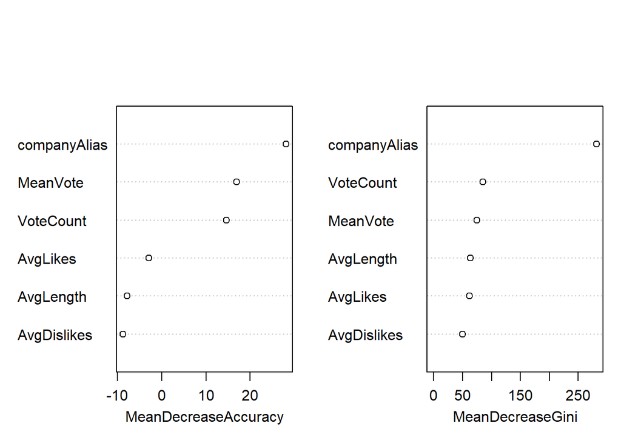

```r
varImpPlot(model1, main="")
```

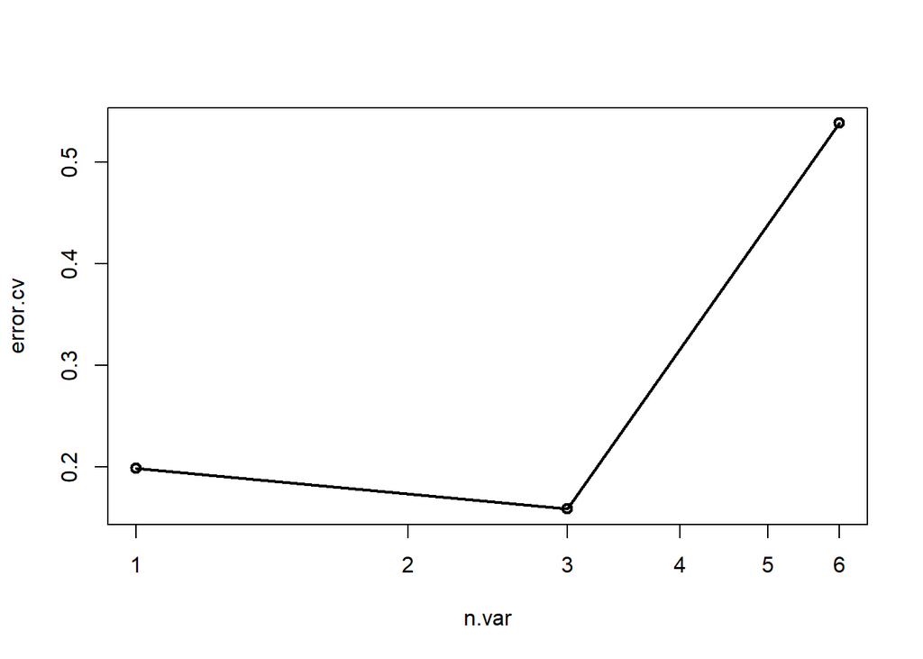

```r
Emp_trainx <- dplyr::select(EmpCom_train, -stillExists)
result <- rfcv(Emp_trainx, EmpCom_train$stillExists, cv.fold=10)
with(result, plot(n.var, error.cv, log="x", type="o", lwd=2))
```

```r
model2 <- randomForest(stillExists ~ ., data=EmpCom_train,
                          ntree=4000,
                          sampsize=c(500,500),
                          strata=EmpCom_train$stillExists,
                          mtry=2,
                          importance=TRUE,
                          na.action=na.roughfix,
                          replace=FALSE)
model2
```

```
##
## Call:
##  randomForest(formula = stillExists ~ ., data = EmpCom_train,      ntree = 4000, sampsize = c(500, 500), strata = EmpCom_train$stillExists,      mtry = 2, importance = TRUE, replace = FALSE, na.action = na.roughfix)
##                Type of random forest: classification
##                      Number of trees: 4000
## No. of variables tried at each split: 2
##
##         OOB estimate of  error rate: 70.09%
## Confusion matrix:
##       false true class.error
## false   743   22  0.02875817
## true   2352  270  0.89702517
```

```r
rn <- round(importance(model2), 2)
rn[order(rn[,3], decreasing=TRUE),]
```

```
##              false   true MeanDecreaseAccuracy MeanDecreaseGini
## companyAlias 91.55  31.05                61.29           222.99
## MeanVote     63.54 -13.05                12.10            50.02
## VoteCount    81.92 -34.30                -6.72            60.47
## AvgLikes     81.31 -48.04               -39.03            36.72
## AvgDislikes  67.75 -52.60               -45.22            29.10
## AvgLength    73.93 -52.24               -45.41            35.15
```

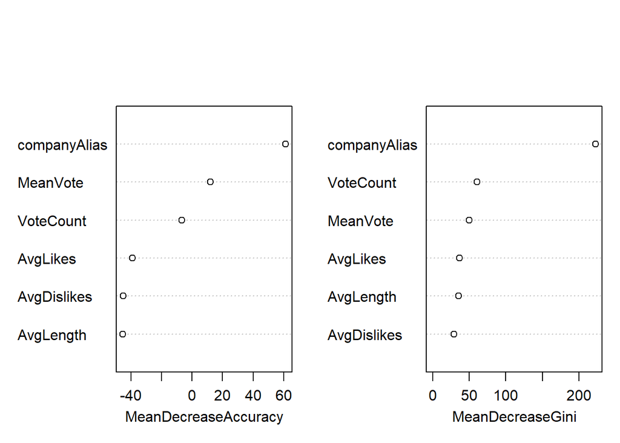

```r
varImpPlot(model2, main="")
```

Moving forward, I attempted to stratify the data to increase the prevalence of the rare false result of stillExists. This was even less effective, but I learned some important information and tuned accordingly

```r
model3 <- randomForest(stillExists ~ companyAlias + MeanVote + VoteCount + AvgLikes, data=EmpCom_train,
                    ntree=4000,
                    sampsize=c(20,1000),
                    strata=EmpCom_train$stillExists,
                    mtry=2,
                    importance=TRUE,
                    na.action=na.roughfix,
                    replace=FALSE)
model3
```

```
##
## Call:
##  randomForest(formula = stillExists ~ companyAlias + MeanVote +      VoteCount + AvgLikes, data = EmpCom_train, ntree = 4000,      sampsize = c(20, 1000), strata = EmpCom_train$stillExists,      mtry = 2, importance = TRUE, replace = FALSE, na.action = na.roughfix)
##                Type of random forest: classification
##                      Number of trees: 4000
## No. of variables tried at each split: 2
##
##         OOB estimate of  error rate: 26.25%
## Confusion matrix:
##       false true class.error
## false   164  601   0.7856209
## true    288 2334   0.1098398
```

```r
rn <- round(importance(model3), 2)
rn[order(rn[,3], decreasing=TRUE),]
```

```
##              false  true MeanDecreaseAccuracy MeanDecreaseGini
## companyAlias 70.85 39.01                72.10             7.42
## VoteCount    53.91 16.85                54.21             9.44
## AvgLikes     49.70 10.00                39.56             7.79
## MeanVote     43.19  2.64                36.94             9.95
```

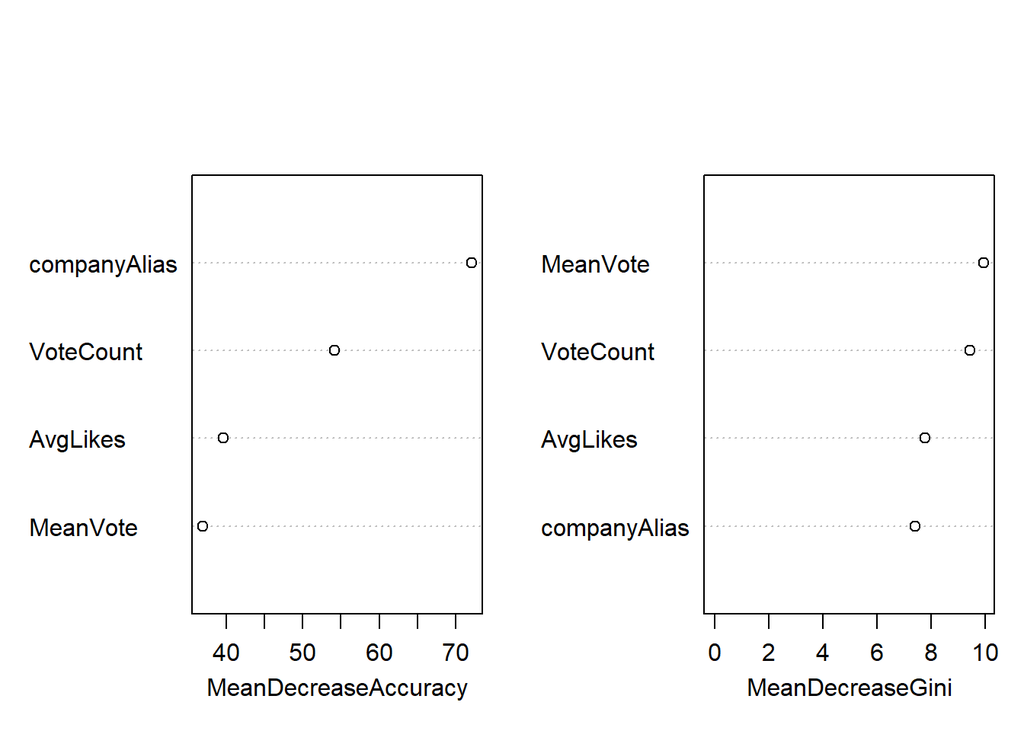

```r
varImpPlot(model3, main="")
```

Overall a bit better than previous iterations, but still far from the predictive power desired. Moving into the final leg of the project I know I needed to make significant improvements to the model. I intend to attempt a more effective means of stratifying the data going foward, but I may switch to classwt if it proves ineffective,